**City College of San Francisco**

MATH 108 - Foundations of Data Science

# Lecture 10: Groups

Associated Textbook Sections: [8.2, 8.3](https://inferentialthinking.com/chapters/08/2/Classifying_by_One_Variable.html)

## Set Up the Notebook

```python
from datascience import *
import numpy as np
%matplotlib inline
import matplotlib.pyplot as plots
plots.style.use('fivethirtyeight')
#import warnings
#warnings.simplefilter(action='ignore',category=np.VisibleDeprecationWarning)
```

# Table of Contents

## Sir Francis Galton

- 1822 - 1911 (knighted in 1909)
- Charles Darwin's half-cousin
- Developed systems for making predictions in several fields
- An advocate for eugenics and scientific racism

[figure not shown]

## Prediction

### Demo: Prediction

Load the Galton's data and visualize the relationship between `midparentHeight` and `childHeight`.

```python
galton = Table.read_table('galton.csv')
galton
```

| family | father | mother | midparentHeight | children | childNum | sex | childHeight |
| --- | --- | --- | --- | --- | --- | --- | --- |
| 1 | 78.5 | 67 | 75.43 | 4 | 1 | male | 73.2 |
| 1 | 78.5 | 67 | 75.43 | 4 | 2 | female | 69.2 |
| 1 | 78.5 | 67 | 75.43 | 4 | 3 | female | 69 |
| 1 | 78.5 | 67 | 75.43 | 4 | 4 | female | 69 |
| 2 | 75.5 | 66.5 | 73.66 | 4 | 1 | male | 73.5 |
| 2 | 75.5 | 66.5 | 73.66 | 4 | 2 | male | 72.5 |
| 2 | 75.5 | 66.5 | 73.66 | 4 | 3 | female | 65.5 |
| 2 | 75.5 | 66.5 | 73.66 | 4 | 4 | female | 65.5 |
| 3 | 75 | 64 | 72.06 | 2 | 1 | male | 71 |
| 3 | 75 | 64 | 72.06 | 2 | 2 | female | 68 |

... (924 rows omitted)

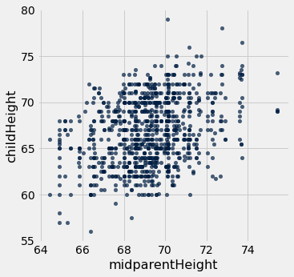

```python
galton.scatter('midparentHeight', 'childHeight')
```

Identify points that are within 0.5 of the `midparentHeight` value of 68.

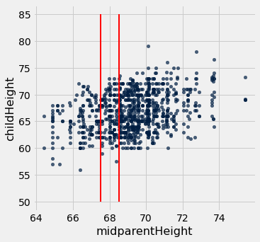

```python
galton.scatter('midparentHeight', 'childHeight')
plots.plot([67.5, 67.5], [50, 85], color='red', lw=2)
plots.plot([68.5, 68.5], [50, 85], color='red', lw=2);
```

```python
nearby = galton.where('midparentHeight', are.between(67.5, 68.5))
nearby_mean = np.mean(nearby.column('childHeight'))
nearby_mean
```

```
66.24045801526718
```

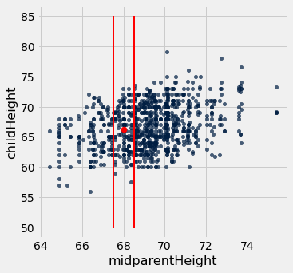

```python
galton.scatter('midparentHeight', 'childHeight')
plots.plot([67.5, 67.5], [50, 85], color='red', lw=2)
plots.plot([68.5, 68.5], [50, 85], color='red', lw=2)
plots.scatter(68, nearby_mean, color='red', s=50);
```

Create a function to predict the height of a child based on the average `childHeight` associated with the points within 0.5 of the given child's `midparentHeight` value.

```python
def predict(h):
    '''Predict a child height based on a midparent height (h)'''
    nearby = galton.where('midparentHeight', are.between(h - 0.5, h + 0.5))
    return np.mean(nearby.column('childHeight'))
```

```python
predict(68)
```

```
66.24045801526718
```

Apply the function to the `galton` table.

```python
predicted_heights = galton.apply(predict, 'midparentHeight')
predicted_heights
```

```
array([70.1       , 70.1       , 70.1       , 70.1       , 70.41578947,
       70.41578947, 70.41578947, 70.41578947, 68.5025    , 68.5025    ,
       68.5025    , 68.5025    , 68.5025    , 68.5025    , 68.5025    ,
       66.43149606, 66.43149606, 66.43149606, 66.43149606, 66.43149606,
       66.43149606, 70.41578947, 70.41578947, 70.41578947, 70.41578947,
       70.41578947, 70.41578947, 70.41578947, 69.18571429, 69.18571429,
       69.18571429, 69.18571429, 68.66052632, 67.63423913, 67.63423913,
       67.63423913, 67.63423913, 67.63423913, 67.63423913, 67.63423913,
       67.63423913, 67.37410714, 68.77428571, 68.77428571, 68.77428571,
       68.77428571, 68.59230769, 68.59230769, 68.59230769, 68.07323944,
       68.07323944, 68.07323944, 68.07323944, 68.07323944, 68.07323944,
       68.07323944, 68.07323944, 68.07323944, 68.05465116, 68.05465116,
       68.05465116, 68.05465116, 68.05465116, 68.05465116, 67.56276596,
       67.56276596, 67.56276596, 67.71678832, 70.41578947, 70.41578947,
       70.41578947, 70.41578947, 70.41578947, 70.41578947, 70.41578947,
       70.41578947, 68.628125  , 68.628125  , 68.628125  , 68.54193548,
       68.54193548, 68.54193548, 67.66941176, 67.66941176, 67.66941176,
       67.66941176, 67.66941176, 67.66941176, 67.66941176, 68.05357143,
       67.63352941, 67.63352941, 67.36355556, 67.36355556, 67.36355556,
       67.36355556, 67.36355556, 67.36355556, 67.36355556, 67.36355556,
       67.36355556, 67.36355556, 67.36355556, 67.36355556, 67.36355556,
       67.36355556, 67.63352941, 67.63352941, 67.63352941, 66.75884956,
       67.11255061, 67.11255061, 67.11255061, 67.11255061, 67.11255061,
       67.11255061, 66.75884956, 66.75884956, 66.75884956, 66.75884956,
       66.75884956, 66.75884956, 66.75884956, 66.75884956, 66.75884956,
       66.75884956, 66.23647541, 68.628125  , 68.628125  , 68.628125  ,
       68.628125  , 68.628125  , 67.97333333, 67.97333333, 67.97333333,
       67.97333333, 67.85      , 67.85      , 67.85      , 67.85      ,
       67.85      , 67.85      , 67.85      , 67.85      , 67.85      ,
       67.85      , 67.85      , 67.85      , 67.85      , 67.85      ,
       67.85      , 67.85      , 67.85      , 67.97294118, 67.8661157 ,
       67.8661157 , 67.8661157 , 67.8661157 , 67.8661157 , 67.8661157 ,
       67.79340659, 67.79340659, 67.75384615, 67.75384615, 67.67204969,
       67.67204969, 67.67204969, 67.38465116, 67.38465116, 67.38465116,
       67.38465116, 67.38465116, 67.38465116, 67.38465116, 67.38465116,
       67.78319328, 67.78319328, 67.78319328, 67.78319328, 67.38465116,
       67.38465116, 67.38465116, 67.62469136, 67.62469136, 67.62469136,
       67.62469136, 67.62469136, 67.62469136, 67.62469136, 67.53815029,
       67.53815029, 66.89330544, 66.89330544, 67.11359649, 67.11359649,
       67.11359649, 67.11359649, 67.11359649, 66.74257426, 66.74257426,
```

[output cut: 132 more lines]

```
       66.26966825, 66.26966825, 66.26966825, 66.26966825, 66.35481928,
       66.35481928, 66.35481928, 66.35481928, 66.35481928, 66.35481928,
       66.35481928, 66.35481928, 66.35481928, 66.36513761, 66.36513761,
       66.36513761, 66.36513761, 66.36513761, 66.36513761, 66.36513761,
       66.36513761, 66.36513761, 65.99259259, 65.99259259, 66.36513761,
       66.36513761, 66.36513761, 66.36513761, 66.36513761, 66.36513761,
       65.55833333, 65.55833333, 65.55833333, 65.55833333, 65.55833333,
       65.55833333, 65.21690141, 65.21690141, 65.21690141, 65.21690141,
       65.21690141, 65.36296296, 65.36296296, 65.36296296, 65.36296296,
       64.22962963, 64.22962963, 64.22962963, 64.22962963, 64.22962963,
       65.2943662 , 65.2943662 , 65.2943662 , 65.2943662 , 65.2943662 ,
       65.2943662 , 65.2943662 , 65.2943662 , 65.2943662 , 65.2943662 ,
       65.2943662 , 65.2943662 , 65.2943662 , 65.2943662 , 64.42121212,
       63.51176471, 63.51176471, 65.11      , 65.11      , 65.15657895,
       65.15657895, 65.15657895, 64.22962963, 64.22962963])
```

```python
galton = galton.with_column('predictedHeight', predicted_heights)
galton
```

| family | father | mother | midparentHeight | children | childNum | sex | childHeight | predictedHeight |
| --- | --- | --- | --- | --- | --- | --- | --- | --- |
| 1 | 78.5 | 67 | 75.43 | 4 | 1 | male | 73.2 | 70.1 |
| 1 | 78.5 | 67 | 75.43 | 4 | 2 | female | 69.2 | 70.1 |
| 1 | 78.5 | 67 | 75.43 | 4 | 3 | female | 69 | 70.1 |
| 1 | 78.5 | 67 | 75.43 | 4 | 4 | female | 69 | 70.1 |
| 2 | 75.5 | 66.5 | 73.66 | 4 | 1 | male | 73.5 | 70.4158 |
| 2 | 75.5 | 66.5 | 73.66 | 4 | 2 | male | 72.5 | 70.4158 |
| 2 | 75.5 | 66.5 | 73.66 | 4 | 3 | female | 65.5 | 70.4158 |
| 2 | 75.5 | 66.5 | 73.66 | 4 | 4 | female | 65.5 | 70.4158 |
| 3 | 75 | 64 | 72.06 | 2 | 1 | male | 71 | 68.5025 |
| 3 | 75 | 64 | 72.06 | 2 | 2 | female | 68 | 68.5025 |

... (924 rows omitted)

Visualize the predictions.

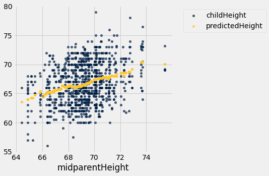

```python
galton.select('midparentHeight', 'childHeight', 'predictedHeight').scatter('midparentHeight')
```

## Prediction Accuracy

### Demo: Prediction Accuracy

Define a function to compute the difference `x - y` between two values `x` and `y`.

```python
def difference(x, y):
    return x - y
```

Apply the function to the `galton` table to measure the difference between the `predictedHeight` and `childHeight` values. Add the results to the table.

```python
pred_errors = galton.apply(difference, 'predictedHeight', 'childHeight')
pred_errors
```

```
array([-3.10000000e+00,  9.00000000e-01,  1.10000000e+00,  1.10000000e+00,
       -3.08421053e+00, -2.08421053e+00,  4.91578947e+00,  4.91578947e+00,
       -2.49750000e+00,  5.02500000e-01, -1.99750000e+00,  2.50000000e-03,
        1.50250000e+00,  4.00250000e+00,  5.50250000e+00, -5.56850394e+00,
       -2.56850394e+00, -1.56850394e+00, -6.85039370e-02,  3.93149606e+00,
        3.93149606e+00,  9.15789474e-01, -6.08421053e+00, -3.58421053e+00,
       -2.58421053e+00, -2.58421053e+00, -8.42105263e-02,  6.41578947e+00,
       -1.31428571e+00,  1.18571429e+00,  3.18571429e+00,  3.18571429e+00,
        3.16052632e+00, -6.36576087e+00, -2.36576087e+00, -3.65760870e-01,
        6.34239130e-01,  6.34239130e-01,  1.63423913e+00,  4.13423913e+00,
        4.63423913e+00,  2.37410714e+00, -2.22571429e+00,  6.77428571e+00,
        7.74285714e-01,  1.77428571e+00, -2.40769231e+00, -1.90769231e+00,
        1.89230769e+00, -3.92676056e+00, -2.42676056e+00, -2.12676056e+00,
       -2.12676056e+00, -1.12676056e+00, -6.26760563e-01,  1.57323944e+00,
        3.57323944e+00,  4.57323944e+00, -5.94534884e+00, -4.94534884e+00,
       -3.44534884e+00,  5.55465116e+00,  1.55465116e+00,  5.75465116e+00,
        1.56276596e+00,  3.06276596e+00,  3.56276596e+00,  5.01678832e+00,
       -2.78421053e+00, -2.58421053e+00, -2.28421053e+00,  4.15789474e-01,
        1.41578947e+00,  1.91578947e+00,  2.41578947e+00,  4.41578947e+00,
       -4.37187500e+00,  1.28125000e-01,  6.28125000e-01, -4.45806452e+00,
       -2.45806452e+00,  1.54193548e+00, -6.53058824e+00, -2.83058824e+00,
       -1.83058824e+00,  1.66941176e+00,  2.16941176e+00,  2.66941176e+00,
        2.66941176e+00,  2.55357143e+00,  1.63352941e+00,  4.63352941e+00,
       -3.13644444e+00, -3.13644444e+00, -1.63644444e+00,  2.36355556e+00,
        4.36355556e+00, -1.63644444e+00,  3.63555556e-01,  4.36355556e+00,
       -5.63644444e+00,  3.63555556e-01, -3.13644444e+00, -2.63644444e+00,
        8.63555556e-01,  4.36355556e+00,  1.33529412e-01,  4.33529412e-01,
        9.33529412e-01,  2.75884956e+00, -3.88744939e+00, -2.88744939e+00,
       -2.88744939e+00,  1.11255061e+00,  2.11255061e+00,  2.11255061e+00,
       -7.24115044e+00, -5.24115044e+00, -2.24115044e+00, -7.41150442e-01,
        3.25884956e+00, -5.24115044e+00, -4.74115044e+00, -4.74115044e+00,
       -3.24115044e+00, -1.24115044e+00,  5.36475410e-01, -9.37187500e+00,
       -5.37187500e+00, -4.37187500e+00, -3.37187500e+00,  1.62812500e+00,
       -5.22666667e+00, -5.02666667e+00, -1.02666667e+00,  9.73333333e-01,
       -2.15000000e+00,  8.50000000e-01,  8.50000000e-01,  1.35000000e+00,
       -2.15000000e+00, -1.15000000e+00, -6.50000000e-01,  1.85000000e+00,
        3.35000000e+00,  4.85000000e+00, -3.15000000e+00,  8.50000000e-01,
       -8.15000000e+00, -4.15000000e+00, -3.15000000e+00,  1.85000000e+00,
        1.85000000e+00, -2.52705882e+00, -4.13388430e+00, -4.13388430e+00,
       -3.13388430e+00, -1.13388430e+00,  1.86611570e+00,  2.86611570e+00,
```

[output cut: 179 more lines]

```
        1.36513761e+00,  1.36513761e+00,  4.36513761e+00,  4.36513761e+00,
        5.36513761e+00,  7.36513761e+00, -4.70740741e+00,  4.92592593e-01,
       -2.83486239e+00, -2.63486239e+00, -1.63486239e+00, -1.33486239e+00,
        1.86513761e+00,  5.86513761e+00, -1.44166667e+00, -1.44166667e+00,
        1.55833333e+00,  1.55833333e+00,  3.05833333e+00,  5.05833333e+00,
       -4.78309859e+00,  2.21690141e+00, -7.83098592e-01, -7.83098592e-01,
        2.21690141e+00, -5.63703704e+00, -5.63703704e+00, -3.63703704e+00,
        1.86296296e+00, -3.77037037e+00, -3.77037037e+00, -2.77037037e+00,
       -2.77037037e+00,  2.22962963e+00, -6.20563380e+00, -2.70563380e+00,
       -2.05633803e-01,  1.29436620e+00,  3.29436620e+00,  3.29436620e+00,
        4.29436620e+00, -5.20563380e+00, -2.70563380e+00, -1.70563380e+00,
        2.94366197e-01,  1.29436620e+00,  1.29436620e+00,  5.29436620e+00,
       -7.87878788e-02, -2.48823529e+00,  3.51176471e+00, -3.39000000e+00,
        1.61000000e+00,  1.15657895e+00,  3.15657895e+00,  4.15657895e+00,
       -2.27037037e+00,  7.22962963e+00])
```

```python
galton = galton.with_column('errors', pred_errors)
galton
```

| family | father | mother | midparentHeight | children | childNum | sex | childHeight | predictedHeight | errors |
| --- | --- | --- | --- | --- | --- | --- | --- | --- | --- |
| 1 | 78.5 | 67 | 75.43 | 4 | 1 | male | 73.2 | 70.1 | -3.1 |
| 1 | 78.5 | 67 | 75.43 | 4 | 2 | female | 69.2 | 70.1 | 0.9 |
| 1 | 78.5 | 67 | 75.43 | 4 | 3 | female | 69 | 70.1 | 1.1 |
| 1 | 78.5 | 67 | 75.43 | 4 | 4 | female | 69 | 70.1 | 1.1 |
| 2 | 75.5 | 66.5 | 73.66 | 4 | 1 | male | 73.5 | 70.4158 | -3.08421 |
| 2 | 75.5 | 66.5 | 73.66 | 4 | 2 | male | 72.5 | 70.4158 | -2.08421 |
| 2 | 75.5 | 66.5 | 73.66 | 4 | 3 | female | 65.5 | 70.4158 | 4.91579 |
| 2 | 75.5 | 66.5 | 73.66 | 4 | 4 | female | 65.5 | 70.4158 | 4.91579 |
| 3 | 75 | 64 | 72.06 | 2 | 1 | male | 71 | 68.5025 | -2.4975 |
| 3 | 75 | 64 | 72.06 | 2 | 2 | female | 68 | 68.5025 | 0.5025 |

... (924 rows omitted)

Visualize the errors in prediction.

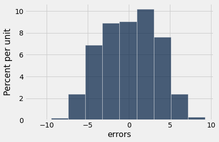

```python
galton.hist('errors')
```

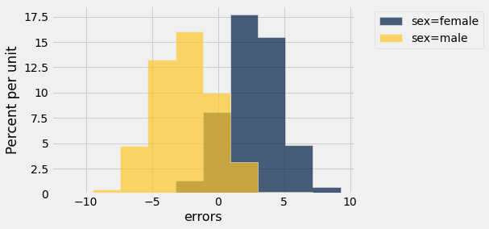

```python
galton.hist('errors', group='sex')
```